# Soccer Analysis Project

### Introduction

I have been recently watching the World Cup 2022 and found the games to be quite exhilerating. Now, we are waiting to see who will win this world cup (I hope it is Argentina). But anyways, watching soccer (or football) has led me interested in the overall game, especially into the players. We are all aware of some of the top players like Lionel Messi and Christian Ronaldo, but what makes them such strong players? We will look into many questions that break down their player stats and see who is the best at certain skillsets. Ultimately, we will looking into which factors help determine how good a player really is.

We will be looking at FIFA data for soccer players because we can get insights into specific features such as their strengths and weakness of the teams thats play in the FIFA World Cup. We can get a sense of which kind of players will perform the best in an international setting as well as understand what strategies different teams may utlize. The goal is to see which soccer stats are effective in determining a soccer player's overall rating. With these features, we can predit a new soccer player's potential rating and and analyze how teams will perform.

### Data Collection

We will be looking at a dataset named "FIFA 2022 complete player dataset" from Kaggle, an online platform where users upload and download certain datasets. This dataset contains the information from "Career Mode" in FIFA 15,16,16,17,18,19,20,21,and 22. For the purpose of this tutorial, we will only be looking FIFA 22 dataset to get the most up to date information about the players. The data had been scrapped from sofifa.com, a website dedicated to updating sport stats and information regarding individual soccer players around the world. Here is the link to the dataset if you are more interested in how the dataset is made, click [this](https://www.kaggle.com/datasets/stefanoleone992/fifa-22-complete-player-dataset?select=players_22.csv).

Here are all the import statements needed to run this tutorial:

```python
import pandas as pd
import seaborn as sns
from matplotlib import pyplot as plt

from collections import defaultdict

from scipy.stats import pearsonr

from sklearn.model_selection import train_test_split
from sklearn.linear_model import LinearRegression
from sklearn.linear_model import LogisticRegression
from sklearn.ensemble import RandomForestRegressor
from sklearn.ensemble import RandomForestClassifier
from sklearn.neighbors import KNeighborsClassifier

from sklearn.metrics import r2_score
from sklearn.metrics import mean_squared_error
from sklearn.metrics import roc_auc_score
from sklearn.metrics import precision_score
from sklearn.metrics import recall_score
from sklearn.metrics import f1_score
from sklearn.metrics import precision_recall_curve
from sklearn.model_selection import GridSearchCV
```

Let's download the Kaggle dataset into a csv (comma-seperated values). A CSV is a standard dataset type that is compatible with the Panda Dataframes library. With this library, we will be able to work with, build, modify, and extract pieces of data from the dataset. First, download the players_22 dataset using [this](https://www.kaggle.com/datasets/stefanoleone992/fifa-22-complete-player-dataset?select=players_22.csv) link. Save it in the same location as the file you are writing your Python script in. To avoid any issues with duplicate files or wrong location, we will be using the whole filepath to find the csv file in your computer and get the data. We will then read the csv file.

```python
dataset = pd.read_csv('/Users/sakethkura/Documents/CMSC320/fall2022/project5/players_22.csv', low_memory=False)
dataset #will show the first 10 rows of the dataset
```

|  | sofifa_id | player_url | short_name | long_name | player_positions | overall | potential | value_eur | wage_eur | age | ... | lcb | cb | rcb | rb | gk | player_face_url | club_logo_url | club_flag_url | nation_logo_url | nation_flag_url |
| --- | --- | --- | --- | --- | --- | --- | --- | --- | --- | --- | --- | --- | --- | --- | --- | --- | --- | --- | --- | --- | --- |
| 0 | 158023 | https://sofifa.com/player/158023/lionel-messi/... | L. Messi | Lionel Andrés Messi Cuccittini | RW, ST, CF | 93 | 93 | 78000000.0 | 320000.0 | 34 | ... | 50+3 | 50+3 | 50+3 | 61+3 | 19+3 | https://cdn.sofifa.net/players/158/023/22_120.png | https://cdn.sofifa.net/teams/73/60.png | https://cdn.sofifa.net/flags/fr.png | https://cdn.sofifa.net/teams/1369/60.png | https://cdn.sofifa.net/flags/ar.png |
| 1 | 188545 | https://sofifa.com/player/188545/robert-lewand... | R. Lewandowski | Robert Lewandowski | ST | 92 | 92 | 119500000.0 | 270000.0 | 32 | ... | 60+3 | 60+3 | 60+3 | 61+3 | 19+3 | https://cdn.sofifa.net/players/188/545/22_120.png | https://cdn.sofifa.net/teams/21/60.png | https://cdn.sofifa.net/flags/de.png | https://cdn.sofifa.net/teams/1353/60.png | https://cdn.sofifa.net/flags/pl.png |
| 2 | 20801 | https://sofifa.com/player/20801/c-ronaldo-dos-... | Cristiano Ronaldo | Cristiano Ronaldo dos Santos Aveiro | ST, LW | 91 | 91 | 45000000.0 | 270000.0 | 36 | ... | 53+3 | 53+3 | 53+3 | 60+3 | 20+3 | https://cdn.sofifa.net/players/020/801/22_120.png | https://cdn.sofifa.net/teams/11/60.png | https://cdn.sofifa.net/flags/gb-eng.png | https://cdn.sofifa.net/teams/1354/60.png | https://cdn.sofifa.net/flags/pt.png |
| 3 | 190871 | https://sofifa.com/player/190871/neymar-da-sil... | Neymar Jr | Neymar da Silva Santos Júnior | LW, CAM | 91 | 91 | 129000000.0 | 270000.0 | 29 | ... | 50+3 | 50+3 | 50+3 | 62+3 | 20+3 | https://cdn.sofifa.net/players/190/871/22_120.png | https://cdn.sofifa.net/teams/73/60.png | https://cdn.sofifa.net/flags/fr.png | NaN | https://cdn.sofifa.net/flags/br.png |
| 4 | 192985 | https://sofifa.com/player/192985/kevin-de-bruy... | K. De Bruyne | Kevin De Bruyne | CM, CAM | 91 | 91 | 125500000.0 | 350000.0 | 30 | ... | 69+3 | 69+3 | 69+3 | 75+3 | 21+3 | https://cdn.sofifa.net/players/192/985/22_120.png | https://cdn.sofifa.net/teams/10/60.png | https://cdn.sofifa.net/flags/gb-eng.png | https://cdn.sofifa.net/teams/1325/60.png | https://cdn.sofifa.net/flags/be.png |
| ... | ... | ... | ... | ... | ... | ... | ... | ... | ... | ... | ... | ... | ... | ... | ... | ... | ... | ... | ... | ... | ... |
| 19234 | 261962 | https://sofifa.com/player/261962/defu-song/220002 | Song Defu | 宋德福 | CDM | 47 | 52 | 70000.0 | 1000.0 | 22 | ... | 46+2 | 46+2 | 46+2 | 48+2 | 15+2 | https://cdn.sofifa.net/players/261/962/22_120.png | https://cdn.sofifa.net/teams/112541/60.png | https://cdn.sofifa.net/flags/cn.png | NaN | https://cdn.sofifa.net/flags/cn.png |
| 19235 | 262040 | https://sofifa.com/player/262040/caoimhin-port... | C. Porter | Caoimhin Porter | CM | 47 | 59 | 110000.0 | 500.0 | 19 | ... | 44+2 | 44+2 | 44+2 | 48+2 | 14+2 | https://cdn.sofifa.net/players/262/040/22_120.png | https://cdn.sofifa.net/teams/445/60.png | https://cdn.sofifa.net/flags/ie.png | NaN | https://cdn.sofifa.net/flags/ie.png |
| 19236 | 262760 | https://sofifa.com/player/262760/nathan-logue/... | N. Logue | Nathan Logue-Cunningham | CM | 47 | 55 | 100000.0 | 500.0 | 21 | ... | 45+2 | 45+2 | 45+2 | 47+2 | 12+2 | https://cdn.sofifa.net/players/262/760/22_120.png | https://cdn.sofifa.net/teams/111131/60.png | https://cdn.sofifa.net/flags/ie.png | NaN | https://cdn.sofifa.net/flags/ie.png |
| 19237 | 262820 | https://sofifa.com/player/262820/luke-rudden/2... | L. Rudden | Luke Rudden | ST | 47 | 60 | 110000.0 | 500.0 | 19 | ... | 26+2 | 26+2 | 26+2 | 32+2 | 15+2 | https://cdn.sofifa.net/players/262/820/22_120.png | https://cdn.sofifa.net/teams/111131/60.png | https://cdn.sofifa.net/flags/ie.png | NaN | https://cdn.sofifa.net/flags/ie.png |
| 19238 | 264540 | https://sofifa.com/player/264540/emanuel-lalch... | E. Lalchhanchhuaha | Emanuel Lalchhanchhuaha | CAM | 47 | 60 | 110000.0 | 500.0 | 19 | ... | 41+2 | 41+2 | 41+2 | 45+2 | 16+2 | https://cdn.sofifa.net/players/264/540/22_120.png | https://cdn.sofifa.net/teams/113040/60.png | https://cdn.sofifa.net/flags/in.png | NaN | https://cdn.sofifa.net/flags/in.png |

19239 rows × 110 columns

### Data Management

For this tutorial, we will only be looking at a few features and analyze them to see how impactful they are to the overall rating of the player. This is because not only does this dataset have unrelated information such as URLs to logos, photos, and stat websites, but we will try to simplify the data analysis as much as possible so we can learn the most about the data. If were to include all of the columns into our analysis, we could be exploring our data for days. So, let's focus on only a few relevant aspects that can relate to a player's overall rating.

Let's look at the following player skills: pace, shooting, passing, dribbling, defending, and physique. There are many other fields that we can look into, but I chose these because these the are primary skills related to soccer. According to the [Soccer Training Guide](http://www.soccer-training-guide.com/basic-soccer-skill.html), the most important skills are passing, receiving, trapping(receiving the ball while standing still), and shooting. I incorporated most of these skills, and added defending because a soccer player should be well rounded and not just focused on offense and and physique is an important measurement as to how fit a player is, meaning they are capable of physically performing better than others.

We won't be needing the player's names because we will ultimately be observing how certain stats affect a player's overall score, so we will not be conducting analysis on individual players, but rather players in the entire dataset.

Overall, we will be looking at the following features to predict a player's overall rating:

- Nationality
- Age
- Shooting
- Passing
- Dribbling
- Defending
- Physique

We need to extract these certain columns from our dataset. Also, if we take a look at the physique column, it is misspelled, so we will fix the spelling in the updated dataset. We will include the player_position column not as a feature, but as as category to classify for later.

Since some players have multiple player positions, we will pick the first one because that is their preferred one.

```python
columns = ['overall', 'nationality_name','age', 'shooting','passing', 'dribbling', 'defending', 'physic', 'player_positions']
df = dataset[columns]
df['player_positions'] = df['player_positions'].apply(lambda x:x.split(", ")[0])
df = df.rename(columns={"physic": "physique"})
df
```

|  | overall | nationality_name | age | shooting | passing | dribbling | defending | physique | player_positions |
| --- | --- | --- | --- | --- | --- | --- | --- | --- | --- |
| 0 | 93 | Argentina | 34 | 92.0 | 91.0 | 95.0 | 34.0 | 65.0 | RW |
| 1 | 92 | Poland | 32 | 92.0 | 79.0 | 86.0 | 44.0 | 82.0 | ST |
| 2 | 91 | Portugal | 36 | 94.0 | 80.0 | 88.0 | 34.0 | 75.0 | ST |
| 3 | 91 | Brazil | 29 | 83.0 | 86.0 | 94.0 | 37.0 | 63.0 | LW |
| 4 | 91 | Belgium | 30 | 86.0 | 93.0 | 88.0 | 64.0 | 78.0 | CM |
| ... | ... | ... | ... | ... | ... | ... | ... | ... | ... |
| 19234 | 47 | China PR | 22 | 35.0 | 46.0 | 48.0 | 42.0 | 49.0 | CDM |
| 19235 | 47 | Republic of Ireland | 19 | 39.0 | 50.0 | 46.0 | 41.0 | 51.0 | CM |
| 19236 | 47 | Republic of Ireland | 21 | 37.0 | 45.0 | 49.0 | 41.0 | 52.0 | CM |
| 19237 | 47 | Republic of Ireland | 19 | 46.0 | 36.0 | 48.0 | 15.0 | 42.0 | ST |
| 19238 | 47 | India | 19 | 38.0 | 45.0 | 48.0 | 36.0 | 48.0 | CAM |

19239 rows × 9 columns

This dataset looks alot more approachable. We can see each of the individual columns we want to analyze without needing to scroll through all of them.

Our first exploratory analysis will consist of looking at the distributions of these features grouped by country. We are interested in seeing what kind of players each nationality has. Does Argentina have strong shooters? Does Spain have players that are good at playing defensively? To do this, we need to ensure each player has a nationality, otherwise we could be dealing with empty data. To do this, we check if any entries in the nationality column is not null. After ensuring there are no null values in the nationality column, we will get the counts for each nationality.

```python
print("length of dataset before reduction: ", len(df))
nations = df[df['nationality_name'].notnull()]
print("length of dataset after reduction: ", len(nations))
print("Number of countries: ", len(nations['nationality_name'].unique()))
df['nationality_name'].value_counts()[:15]
```

```
length of dataset before reduction:  19239
length of dataset after reduction:  19239
Number of countries:  163
```

```
England                1719
Germany                1214
Spain                  1086
France                  980
Argentina               960
Brazil                  897
Japan                   546
Netherlands             439
United States           413
Poland                  403
China PR                385
Sweden                  385
Norway                  379
Republic of Ireland     374
Portugal                373
Name: nationality_name, dtype: int64
```

From the nations data, we can see there are over 160 countries that are listed. Because it is very difficult to observe every distribution for every single country, so we will instead be looking at the stats for the top 15 countries, ranked from most data entries to least. This way, we can potentially see trends determined for many data points, not just a few. With more players per country, the more insight we can get. We will get the top 15 nations from that list and then get the rows that include those top 15 nations. We will also create an other group to represent a group of players from the non top 15 countrie. Since this group is very large, we will randomly sample 370 entries to get a representative amount. This amount will be the 16th group, which will be less than in size to the 15th country Portugal. We will consider "Other" as a nation.

```python
ordered_nations = nations['nationality_name'].value_counts().index.tolist()
other = ordered_nations[15:]
ordered_nations = ordered_nations[:15]
on_data = nations.loc[nations['nationality_name'].isin(ordered_nations)]
otherdata = nations.loc[nations['nationality_name'].isin(other)]
otherdata = otherdata.sample(n=370, random_state=42)
otherdata['nationality_name'].value_counts()
```

```
Italy              22
Korea Republic     18
Saudi Arabia       17
Mexico             17
Austria            16
                   ..
Syria               1
Guyana              1
North Macedonia     1
Congo               1
Ghana               1
Name: nationality_name, Length: 67, dtype: int64
```

Now that we have our top 16 nations dataset, we need to make sure that each of the factors we are looking into have no empty values. Let's repeat the filtering process for each of the factors.

```python
otherdata['nationality_name'] = "Other"
on_data = pd.concat([on_data, otherdata], ignore_index = True, sort = False)
print(on_data['shooting'].isna().sum())
print(on_data['age'].isna().sum())
print(on_data['passing'].isna().sum())
print(on_data['defending'].isna().sum())
print(on_data['dribbling'].isna().sum())
print(on_data['physique'].isna().sum())
print(on_data['overall'].isna().sum())
print(on_data['player_positions'].isna().sum())
```

```
1237
0
1237
1237
1237
1237
0
0
```

Since some of the feature columns have missing values, we will replace them with their associated average values

```python
skills = on_data
skills['shooting'].fillna(value=skills['shooting'].mean(), inplace=True)
skills['passing'].fillna(value=skills['passing'].mean(), inplace=True)
skills['dribbling'].fillna(value=skills['dribbling'].mean(), inplace=True)
skills['defending'].fillna(value=skills['defending'].mean(), inplace=True)
skills['physique'].fillna(value=skills['physique'].mean(), inplace=True)

print(on_data['shooting'].isna().sum())
print(on_data['age'].isna().sum())
print(on_data['passing'].isna().sum())
print(on_data['defending'].isna().sum())
print(on_data['dribbling'].isna().sum())
print(on_data['physique'].isna().sum())
print(on_data['overall'].isna().sum())
print(on_data['player_positions'].isna().sum())
```

```
0
0
0
0
0
0
0
0
```

Let's also make a dataset for the player's weekly wage in euros. This dataset will focus on features not directly related to a player's overall rating and instead for us to do some analysis based on the nations. We will also only focus on the top 15 nations with the most players so we will filter those again. Since this is a side exploration, we will only focus on the top 15 countries for this.

```python
special = dataset[['nationality_name', 'wage_eur']]
special = special.loc[special['nationality_name'].isin(ordered_nations)]
special = special.reset_index()
special
```

|  | index | nationality_name | wage_eur |
| --- | --- | --- | --- |
| 0 | 0 | Argentina | 320000.0 |
| 1 | 1 | Poland | 270000.0 |
| 2 | 2 | Portugal | 270000.0 |
| 3 | 3 | Brazil | 270000.0 |
| 4 | 6 | France | 230000.0 |
| ... | ... | ... | ... |
| 10548 | 19233 | Republic of Ireland | 500.0 |
| 10549 | 19234 | China PR | 1000.0 |
| 10550 | 19235 | Republic of Ireland | 500.0 |
| 10551 | 19236 | Republic of Ireland | 500.0 |
| 10552 | 19237 | Republic of Ireland | 500.0 |

10553 rows × 3 columns

Now that are data is processed, we can finally start some data analysis!

### Exploratory Data Analysis

To make the plots in the tutorial, we will be using the seaborn library. This library is very friendly with pandas and is capable of generating beautiful plots with only a few lines of code. This will be helpful for us as it does not overcomplicated the plotting process. Matplotlib is another option for plotting data, but I think seaborn plots have a better appearance due to their design and color choices.

First, let's conduct some analysis on the special dataset. I want to know how much these nations pay for their professional players. Do they range and vary between nation? Let's find out!

```python
#Creating wage lists for each country, where each player from that country's wage is
#in that list
sum_wages = {}

for i in ordered_nations:
    sum_wages[i] = []

for r in special.itertuples(index=False):
    wage = r[2]
    nat = r[1]
    sum_wages[nat].append(wage)

for i in sum_wages:
    if len(sum_wages[i]) != 0:
        sum_wages[i]  = sum(sum_wages[i])/len(sum_wages[i])
    else:
        sum_wages[i]  = 0
```

Now, let's make a barplot for the weekly wages. I did not use wages because these can be negotiated/external factors that can decide that value. Therefore, it is not necessarily a good indicator of how a player is. We will be using plt's bar function. We are using plt for this barplot because seaborn is a bit stubborn when working with dictonaries, while plt is capable of working with more flexible data structures. Because the nationalities are long, we will abbreviate them with two letters. To learn more about plt's bar, click [this](https://matplotlib.org/stable/api/_as_gen/matplotlib.pyplot.bar.html).

```
EN stands for England
GE stands for Germany
SP stands for Spain
FR stands for France
AR stands for Argentina
BR stands for Brazil
JP stands for Japan
NL stands for Netherlands
US stands for United States
CH stands for China
NO stands for Norway
PT stands for Portugal
```

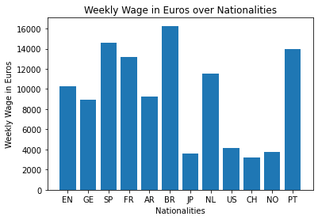

```python
plt.title('Weekly Wage in Euros over Nationalities')
plt.xlabel("Nationalities")
plt.ylabel("Weekly Wage in Euros")

#we removed these nations because their salaries were not showing up properly in the
#dataset

del sum_wages["Poland"]
del sum_wages["Sweden"]
del sum_wages["Republic of Ireland"]



plt.bar(['EN', 'GE', 'SP', 'FR', 'AR', 'BR', 'JP', "NL", "US", 'CH', 'NO', 'PT'],sum_wages.values())

print("EN stands for England")
print("GE stands for Germany")
print("SP stands for Spain")
print("FR stands for France")
print("AR stands for Argentina")
print("BR stands for Brazil")
print("JP stands for Japan")
print("NL stands for Netherlands")
print("US stands for United States")
print("CH stands for China")
print("NO stands for Norway")
print("PT stands for Portugal")
```

Let's do some preliminary analysis and look at the general distributions of age and overall rating. We can ask questions like:

- What is the average age of a professional soccer player?
- Are there more young players than older ones?
- What is the average overall rating of a professional soccer player?
- What kinds of players are there?

We will be plotting histograms for age and overall rating. Histograms show the frequency of numerical data point. We also have the option of grouping the numerical variable into intervals and get their frequency as well. They are an appealing plot to display the distribution of a single variable. To learn more about how to use histograms in seaborn, click [this](https://seaborn.pydata.org/generated/seaborn.histplot.html).

```
Age Mean:  25.11068387805548
Age STD:  4.808312242050331
Overall Rating Mean:  66.00219719857182
Overall Rating STD:  6.964686787363362
```

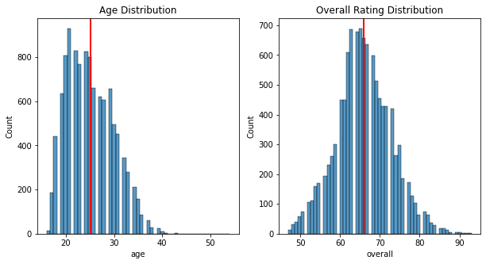

```python
fig, ax = plt.subplots(1,2, figsize=(10, 5))
a = sns.histplot(data=skills, x="age", ax=ax[0])
a.axvline(x=skills['age'].mean(),
            color='red',
            lw=2)
ax[0].set_title("Age Distribution")

b = sns.histplot(data=skills, x="overall", ax=ax[1])
b.axvline(x=skills['overall'].mean(),
            color='red',
            lw=2)
ax[1].set_title("Overall Rating Distribution")

print("Age Mean: ", skills['age'].mean())
print("Age STD: ", skills['age'].std())
print("Overall Rating Mean: ", skills['overall'].mean())
print("Overall Rating STD: ", skills['overall'].std())
```

For the age distribution, it is slightly right skewed, so the majority of the players are to the younger side. In fact, after 40, there are little to no players in sight. For the overall rating distribution, it seems to be approximately normal and centered around the mean. There is decent spread, as the majority of the distribution is within the 60-75 rating range, or within one standard deviation from the mean.

Nations have all kinds of players, so we can ask some questions about them:

- What makes each nation different?
- Do some nations have faster players or better shooters?
- Which nation has the best players overall?

To understand the distributions for each of the top 15 nations, we will be creating a violin plot for each of the skills. A violin plot shows the distribution of numerical data over a categorical variable. It is similar to a box and whisker plot, but instead of showing the lines, the distribution is displayed with a smooth curve. The curve is generated based on the sample size, so to make it as accurate as possible, we need an ample amount of data points. By selecting the top 15 nations, we will have enough data points to make the curve meaningful. We are also using violin plots because they can give insight into the modes of the distribution, potentially multiple modes. To learn more about violin plots, click [this](https://mode.com/blog/violin-plot-examples/).

In our tutorial, we will be using the nationality as the categorical variable and observe the distributions through each of the skill variables.

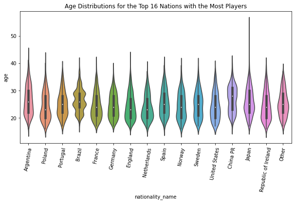

```python
fig, ax = plt.subplots(1,1, figsize=(10, 5))
sns.violinplot(data=skills, x="nationality_name", y="age")
#to make the xticks easier to read, we put them at an angle
ax.set_xticklabels(skills['nationality_name'].unique(), rotation=80)
ax.set_title("Age Distributions for the Top 16 Nations with the Most Players")
```

From the age violin plot, we can see how the average age for playing professional soccer is between 20 and 30, but that varies from nation to nation. For most of the countries like Argentina, France, and Spain, their distributions are skewed right, so the majority of the players are on the younger side. This is expected as the peak age for playing professional soccer is around 25 according the [Athletic](https://theathletic.com/2935360/2021/11/15/what-age-do-players-in-different-positions-peak/). Brazil's multimodal distribution shows that many of its players are of roughly 20, 24, and 30 years old. Japan seems to have a player/players in the 50+ range.

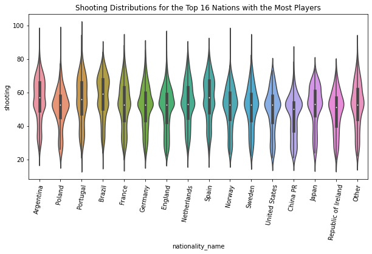

```python
fig, ax = plt.subplots(1,1, figsize=(10, 5))
sns.violinplot(data=skills, x="nationality_name", y="shooting")
ax.set_xticklabels(skills['nationality_name'].unique(), rotation=80)
ax.set_title("Shooting Distributions for the Top 16 Nations with the Most Players")
```

For the shooting violin plot, we can see that there is more spread across the different nations. The distributions are not clumped around the mean but rather spread across the range. There is a general trend where each of the plots are left skewed, so more players are above their nation's average shooting rating. Brazil and Spain are tied for the highest averages in shooting.

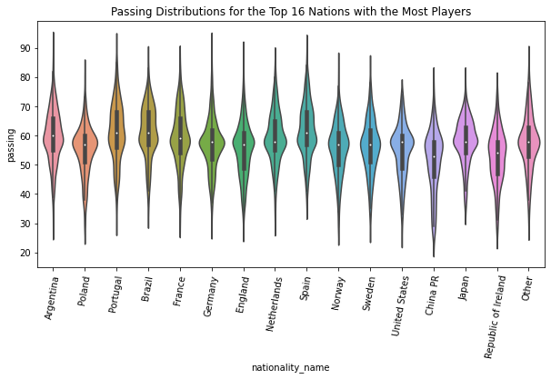

```python
fig, ax = plt.subplots(1,1, figsize=(10, 5))
sns.violinplot(data=skills, x="nationality_name", y="passing")
ax.set_xticklabels(skills['nationality_name'].unique(), rotation=80)
ax.set_title("Passing Distributions for the Top 16 Nations with the Most Players")
```

For the passing violin plot, we can see that most of the distributions are normal being centered around their mean. Japan and Poland are a little more left skewed than the others, but still follow the general normal distribution. There are some potential outliers as many of the nations have very sharp tails and get stretched out on each end.

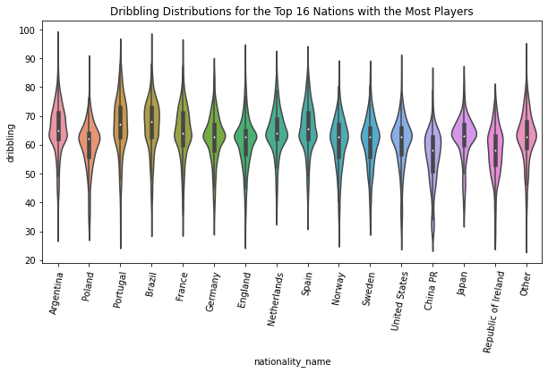

```python
fig, ax = plt.subplots(1,1, figsize=(10, 5))
sns.violinplot(data=skills, x="nationality_name", y="dribbling")
ax.set_xticklabels(skills['nationality_name'].unique(), rotation=80)
ax.set_title("Dribbling Distributions for the Top 16 Nations with the Most Players")
```

For the dribbling violin plot, they show a similar resemblance to the passing distribution from earlier, where each of the distributions looks relatively normal and are generally centered aroud their mean, except for a few nations like Japan. There are also some outliers that stretch out the tails.

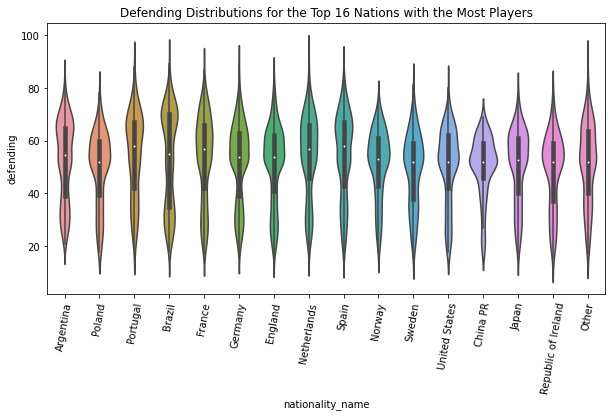

```python
fig, ax = plt.subplots(1,1, figsize=(10, 5))
sns.violinplot(data=skills, x="nationality_name", y="defending")
ax.set_xticklabels(skills['nationality_name'].unique(), rotation=80)
ax.set_title("Defending Distributions for the Top 16 Nations with the Most Players")
```

For the defending distributions, every nation is left skewed, so the majority of the players are approximately above the mean. The tails are not as long as passing or dribbling distributions, so there doesn't seem to be as many outliers as earlier. The overall means are pretty set around 60 with some level of deviation.

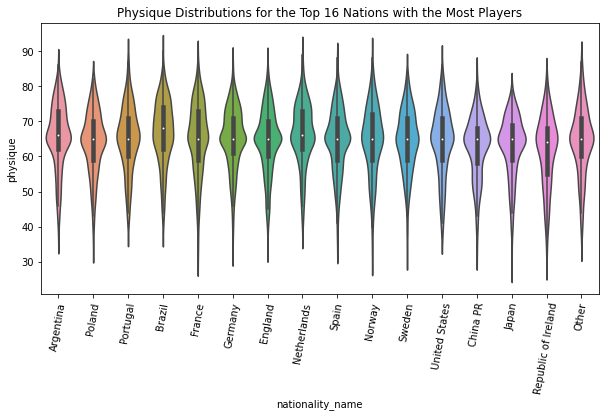

```python
fig, ax = plt.subplots(1,1, figsize=(10, 5))
sns.violinplot(data=skills, x="nationality_name", y="physique")
ax.set_xticklabels(skills['nationality_name'].unique(), rotation=80)
ax.set_title("Physique Distributions for the Top 16 Nations with the Most Players")
```

For the physique distributions, each nationality has a very similar mean. Their distributions are very similar to one another and they are all either approximately normal or leaning to wards being left skewed. Since every nation's mean is centered pretty high, this means that the players in each country have good physiques. This makes sense as professional soccer players need to be able to endure running for long periods of time and being in great shape.

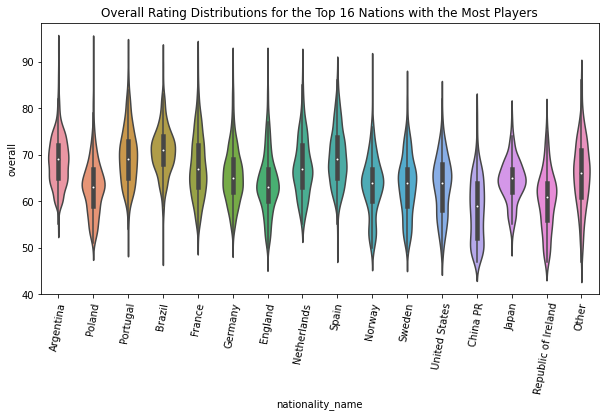

```python
fig, ax = plt.subplots(1,1, figsize=(10, 5))
sns.violinplot(data=skills, x="nationality_name", y="overall")
ax.set_xticklabels(skills['nationality_name'].unique(), rotation=80)
ax.set_title("Overall Rating Distributions for the Top 16 Nations with the Most Players")
```

For the overall rating distribution, the majority of the nations are right skewed, meaning that many of their players have a rating that is below the mean. This means that there are few superstars in each team that drag up the overall nation's rating. This makes sense as all of the players in one nation cannot be amazing, only a few of them will be. For example, Argentina and Portugal's average overall rating is roughly 70, but players like Messi and Ronaldo have ratings in the 90s. We can see Spain and Brazil have distributions with higher means but are also more concentrated around the means, meaning that these countries have players with higher ratings on average.

To understand the outliers in the violin plot, let's redo this plot but with a box plot. A box plot shows a similar distribution for numerical data but instead uses a box that represents 50% of the data near the mean, and the whiskers represent 50% of the data beyond the box. Outliers are then the points that go beyond the whiskers. To learn more about boxplots and how they are used in seaborn, click [this](https://seaborn.pydata.org/generated/seaborn.boxplot.html).

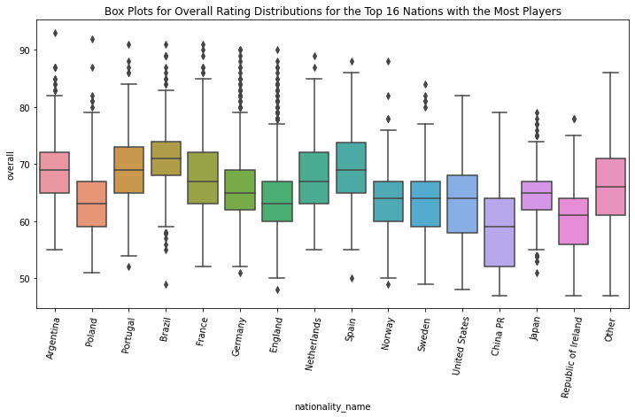

```python
fig, ax =plt.subplots(1,1, figsize=(12, 6))
sns.boxplot(x=skills["nationality_name"], y=skills["overall"])
ax.set_xticklabels(skills['nationality_name'].unique(), rotation=80)
ax.set_title("Box Plots for Overall Rating Distributions for the Top 16 Nations with the Most Players")
```

### Standardization

When working with numerical data, it is important to standardize it because this can help with comparing different variables more easily and locate potential outliers in the data. Below we will standard our skill/physical numerical features.

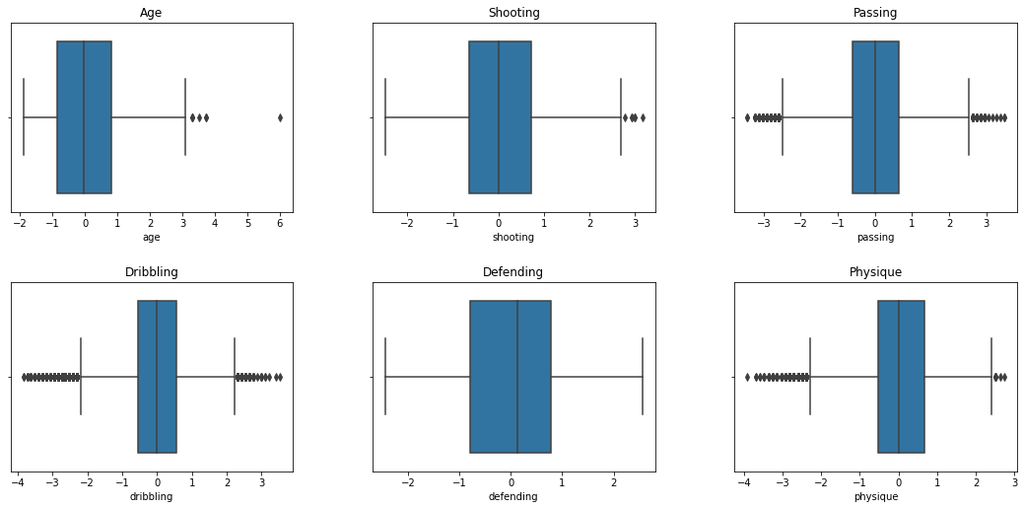

```python
def standardize(name):
    skills[name] = (skills[name] - skills[name].mean()) / skills[name].std()

for c in ["age", "shooting", "passing", "dribbling", "defending", 'physique']:
    standardize(c)

fig, ax =plt.subplots(2,3, figsize=(16, 8))
fig.tight_layout(pad=5.0)

sns.boxplot(x=skills["age"], ax=ax[0][0])
ax[0][0].set_title("Age")

sns.boxplot(x=skills["shooting"], ax=ax[0][1])
ax[0][1].set_title("Shooting")

sns.boxplot(x=skills["passing"], ax=ax[0][2])
ax[0][2].set_title("Passing")

sns.boxplot(x=skills["dribbling"], ax=ax[1][0])
ax[1][0].set_title("Dribbling")

sns.boxplot(x=skills["defending"], ax=ax[1][1])
ax[1][1].set_title("Defending")

sns.boxplot(x=skills["physique"], ax=ax[1][2])
ax[1][2].set_title("Physique")
```

From these plots, we can see how several of them have many outliers. We shall be removing the points that have a standard deviation > 3 or < -3.

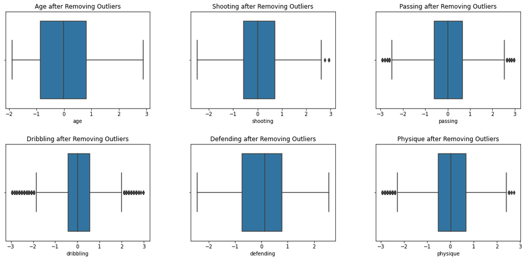

```python
skills = skills[skills['age'].between(-3, 3)]
skills = skills[skills['shooting'].between(-3, 3)]
skills = skills[skills['passing'].between(-3, 3)]
skills = skills[skills['dribbling'].between(-3, 3)]
skills = skills[skills['defending'].between(-3, 3)]
skills = skills[skills['physique'].between(-3, 3)]

fig, ax =plt.subplots(2,3, figsize=(16, 8))
fig.tight_layout(pad=5.0)

s = " after Removing Outliers"

sns.boxplot(x=skills["age"], ax=ax[0][0])
ax[0][0].set_title("Age" + s)

sns.boxplot(x=skills["shooting"], ax=ax[0][1])
ax[0][1].set_title("Shooting" + s)

sns.boxplot(x=skills["passing"], ax=ax[0][2])
ax[0][2].set_title("Passing" + s)

sns.boxplot(x=skills["dribbling"], ax=ax[1][0])
ax[1][0].set_title("Dribbling" + s)

sns.boxplot(x=skills["defending"], ax=ax[1][1])
ax[1][1].set_title("Defending" + s)

sns.boxplot(x=skills["physique"], ax=ax[1][2])
ax[1][2].set_title("Physique" + s)
```

## Hypothesis Testing

#### Feature Correlations

Now, we will look into how the different features correlate with one another and see their level of strength. To do this, we will make a heatmap of the features. Heat maps create a square grid, where the columns and rows are the features, and each cell in the grid find the correlation between those two features. The color represents the strength of correlation, where typically a strong correlation correlates to dark color. This map will help us observe the relationships between the features. We will be using seaborn to make the heat map. To learn more about heat maps, click [this](https://www.naukri.com/learning/articles/heatmap-in-seaborn/).

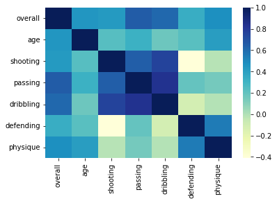

```python
data = skills.drop('nationality_name', axis=1)
data = data.reset_index(drop=True)
sns.heatmap(data.corr(),cmap="YlGnBu");
```

When looking at the heat map, we can positive and negative correlations for different pairs of features. We ignore the diagonal because each cell find the correlation between the same variable, so it will always be strongly correlated. When looking overall rating, it holds a positive correlation with the rest of the features, being more strongly correlated with passing and dribbling. For negative correlation, the strongest cells are between shooting and defending. This makes sense because these features are opposite, as shooters are offensive and defender are defensive. There is little to no correlation between physique and dribbling and physique and shooting. This was unexpecting because to dribble or even shoot, this requires having a good power and speed, which are a part of a good physique.

We should also check to see the correlation coefficients between the rest of the features and the overall rating and see their probability value. The importance of the probability value is to see how significant the correlation is. If the probabliy is less than 0.05, then we can rule the correlation as significant. To do this, we will run a Pearson's test on each of the pairs. Pearson's Test are done to determine the linear correlation between two variables. Althought the variables are not directly linear, they are still a good approach to determining correlation.

To run the Pearson's Test, we will be using scipy, a Python library that is focused on creating functions for data modeling and analysis. In our case, we will use it to run the Pearson's test.

To learn more about Pearson's Test and when to use it, click [this](https://www.scribbr.com/statistics/pearson-correlation-coefficient/).

Let's run the Pearson's Correlation Test for each of the numerical independent variables and see it's correlation with the overall rating.

```python
mldata = skills
#calculate Spearman Rank correlation and corresponding p-valuecc, p = spearmanr(skills['age'], skills['overall'])
cc, p = pearsonr(mldata['age'], mldata['overall'])
print('age')
print("Correlation coefficient: ", cc)
print("p-value: ", p)

cc, p = pearsonr(mldata['shooting'], mldata['overall'])
print('shooting')
print("Correlation coefficient: ", cc)
print("p-value: ", p)

cc, p = pearsonr(mldata['passing'], mldata['overall'])
print('passing')
print("Correlation coefficient: ", cc)
print("p-value: ", p)

cc, p = pearsonr(mldata['dribbling'], mldata['overall'])
print('dribbling')
print("Correlation coefficient: ", cc)
print("p-value: ", p)

cc, p = pearsonr(mldata['defending'], mldata['overall'])
print('defending')
print("Correlation coefficient: ", cc)
print("p-value: ", p)

cc, p = pearsonr(mldata['physique'], mldata['overall'])
print('physique')
print("Correlation coefficient: ", cc)
print("p-value: ", p)
```

```
age
Correlation coefficient:  0.4468053803824067
p-value:  0.0
shooting
Correlation coefficient:  0.42890619931437446
p-value:  0.0
passing
Correlation coefficient:  0.656816441924948
p-value:  0.0
dribbling
Correlation coefficient:  0.611202357133743
p-value:  0.0
defending
Correlation coefficient:  0.3359371296155549
p-value:  2.3203054371269222e-282
physique
Correlation coefficient:  0.47254512091531087
p-value:  0.0
```

Now, it is time to make our machine learning prediction model. Our goal is to predict the overall rating using the selected player's features. We will be creating a Multiple Linear Regression Model. We are essentially running Linear Regression but instead of one variable, we are using several variables. Multiple Linear Regression is good for predicting values and finding the relationships between multiple variables. This model is also relatively simple to implement for a tutorial.

Because we are incorporating the nationality as a factor, we would need to do a one hot encoding or it. Essentially, we will break down this categorical colum and turn it into several boolean columns, one for each of categorical entry. Because there's 160 countries, that is too much to deal with. So, we will go back and use the top 15 countries and work with those. To learn more about this, click [this](https://www.naukri.com/learning/articles/handling-categorical-variables-with-one-hot-encoding/).

We will create the encodings for the nationality column, drop that column from our mldata dataset, then add the encodings to that modified mldata dataset.

```python
nat = pd.get_dummies(mldata['nationality_name'])
mldata = mldata.drop('nationality_name',axis=1)
mldata = pd.concat([mldata, nat], axis=1)
mldata= mldata.reset_index()
mldata.columns
```

```
Index(['index', 'overall', 'age', 'shooting', 'passing', 'dribbling',
       'defending', 'physique', 'player_positions', 'Argentina', 'Brazil',
       'China PR', 'England', 'France', 'Germany', 'Japan', 'Netherlands',
       'Norway', 'Other', 'Poland', 'Portugal', 'Republic of Ireland', 'Spain',
       'Sweden', 'United States'],
      dtype='object')
```

```python
mldata
```

|  | index | overall | age | shooting | passing | dribbling | defending | physique | player_positions | Argentina | ... | Japan | Netherlands | Norway | Other | Poland | Portugal | Republic of Ireland | Spain | Sweden | United States |
| --- | --- | --- | --- | --- | --- | --- | --- | --- | --- | --- | --- | --- | --- | --- | --- | --- | --- | --- | --- | --- | --- |
| 0 | 5 | 90 | 2.056713 | 7.038231e-15 | -2.093702e-13 | 1.358246e-13 | 3.078507e-14 | 1.238508e-13 | GK | 0 | ... | 0 | 0 | 0 | 0 | 0 | 0 | 0 | 0 | 0 | 0 |
| 1 | 6 | 90 | 0.808873 | 7.038231e-15 | -2.093702e-13 | 1.358246e-13 | 3.078507e-14 | 1.238508e-13 | GK | 0 | ... | 0 | 0 | 0 | 0 | 0 | 0 | 0 | 0 | 0 | 0 |
| 2 | 7 | 90 | 0.392927 | 2.926262e+00 | 2.645726e+00 | 2.211194e+00 | -3.356698e-01 | 1.974861e+00 | ST | 0 | ... | 0 | 0 | 0 | 0 | 0 | 0 | 0 | 0 | 0 | 0 |
| 3 | 8 | 90 | 1.016847 | 1.021372e+00 | 1.806829e+00 | 2.101334e+00 | 2.290156e+00 | 1.974861e+00 | CDM | 0 | ... | 0 | 0 | 0 | 0 | 0 | 0 | 0 | 0 | 0 | 0 |
| 4 | 9 | 89 | 1.640766 | 2.545284e+00 | 2.436001e+00 | 2.650633e+00 | -8.608351e-01 | 1.321219e+00 | CF | 0 | ... | 0 | 0 | 0 | 0 | 0 | 0 | 0 | 0 | 0 | 0 |
| ... | ... | ... | ... | ... | ... | ... | ... | ... | ... | ... | ... | ... | ... | ... | ... | ... | ... | ... | ... | ... | ... |
| 10765 | 10918 | 68 | -0.023019 | -8.073227e-01 | -8.068725e-02 | -5.353032e-01 | 1.108535e+00 | 6.675771e-01 | CB | 0 | ... | 0 | 0 | 0 | 1 | 0 | 0 | 0 | 0 | 0 | 0 |
| 10766 | 10919 | 55 | -1.686805 | 7.038231e-15 | -2.093702e-13 | 1.358246e-13 | 3.078507e-14 | 1.238508e-13 | GK | 0 | ... | 0 | 0 | 0 | 1 | 0 | 0 | 0 | 0 | 0 | 0 |
| 10767 | 10920 | 70 | 0.392927 | -2.178844e+00 | -1.758480e+00 | -2.402921e+00 | 1.239826e+00 | 1.539100e+00 | CB | 0 | ... | 0 | 0 | 0 | 1 | 0 | 0 | 0 | 0 | 0 | 0 |
| 10768 | 10921 | 77 | 1.848739 | 1.832203e-01 | 9.679330e-01 | 6.731554e-01 | 1.830637e+00 | 1.103338e+00 | CB | 0 | ... | 0 | 0 | 0 | 1 | 0 | 0 | 0 | 0 | 0 | 0 |
| 10769 | 10922 | 56 | -1.270858 | 1.832203e-01 | -1.653618e+00 | -9.586368e-02 | -2.108103e+00 | -1.620169e+00 | ST | 0 | ... | 0 | 0 | 0 | 1 | 0 | 0 | 0 | 0 | 0 | 0 |

10770 rows × 25 columns

Now we will create the model. We will implement the Holdout Validation, where we hold out a certain percentage of the data to later test with. In our case, we will holdout 20% of our data to test with. We first need to split our data into a training and testing set. We will use this validation approach because it is simple to implement and runs quickly. We do this so we can have an indepdent set for the model to be tested with later. We split the data into the traing and testing set, we then fit the model based on the training data, then we predict the values on the test set. To learn more about Holdout Validation, click [this](https://www.pluralsight.com/guides/validating-machine-learning-models-scikit-learn).

To determine how well the predicted overall ratings were with the actual overall ratings, we will use the mean squared error (MSE). This measurement calculates average squared differences between the prediction and actual values. I chose this because it penalizes large errors more than small ones. To learn more about Multiple Regression Model and the r2 score, click [this](https://www.analyticsvidhya.com/blog/2021/05/multiple-linear-regression-using-python-and-scikit-learn/).

```python
X = mldata.drop(['overall', 'player_positions'], axis=1)
y = mldata['overall']


x_train, x_test, y_train, y_test = train_test_split(X, y, test_size = 0.2,
                                                    random_state = 42)


# creating an object of LinearRegression class
LR = LinearRegression()
# fitting the training data
LR.fit(x_train,y_train)
y_prediction =  LR.predict(x_test)

# predicting the scores
# score=r2_score(y_test,y_prediction)
# print("R2 Score: ", score)
print("MSE: ", mean_squared_error(y_test, y_prediction, squared=True))
```

```
MSE:  3.853728761337193
```

Based on this score, we can say that our model's accuracy is pretty high. Our model fits the data pretty well. This means that our goal has been reached and that our model was able to make good predictons. We can also observe howe well the model performed by looking at its residuals: a measurement of difference between the expected vs predicted value. The lower the residuals, the better our model has performed. Let's see how our residuals are. To learn more about residuals, click [this](https://towardsdatascience.com/how-to-use-residual-plots-for-regression-model-validation-c3c70e8ab378#:~:text=A%20residual%20is%20a%20measure,and%20the%20observed%20actual%20value.).

```python
residuals = y_test - y_prediction
c1 = pd.Series(residuals)
c1 = c1.reset_index()
c2 = pd.Series(y_prediction)
c2.name = 'prediction'
res_plot = pd.concat([c1, c2], axis=1)
res_plot = res_plot.rename(columns={"overall":"residuals"})
res_plot
```

|  | index | residuals | prediction |
| --- | --- | --- | --- |
| 0 | 8904 | -0.066722 | 59.066722 |
| 1 | 1662 | -1.174314 | 74.174314 |
| 2 | 2701 | -0.755796 | 70.755796 |
| 3 | 10353 | -3.673534 | 52.673534 |
| 4 | 7414 | 0.051610 | 61.948390 |
| ... | ... | ... | ... |
| 2149 | 9476 | -1.153755 | 58.153755 |
| 2150 | 7893 | 1.425561 | 60.574439 |
| 2151 | 9592 | 0.083038 | 55.916962 |
| 2152 | 6597 | 0.976945 | 63.023055 |
| 2153 | 4454 | -1.315996 | 68.315996 |

2154 rows × 3 columns

Now, we will look at the relationship between the prediction and the residual. We will be using a scatterplot to display the points. We want to have a scatter plot that is linear centered with a residual at 0. This would mean that that predicted score has no residual, meaning it was the exact score. To learn more about residual plots, click [this](https://www.geeksforgeeks.org/how-to-create-a-residual-plot-in-python/).

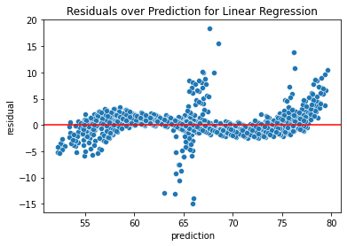

```python
sns.scatterplot(data=res_plot, x="prediction", y='residuals')
plt.ylabel('residual')
plt.axhline(y=0, color='red');
plt.title("Residuals over Prediction for Linear Regression")
```

```python
regressor = RandomForestRegressor(random_state=0)
regressor.fit(x_train, y_train)
y_prediction =  regressor.predict(x_test)
#print("R2 Score: ", r2_score(y_test,y_prediction))
print("MSE: ", mean_squared_error(y_test, y_prediction, squared=True))
```

```
MSE:  0.45687799442896954
```

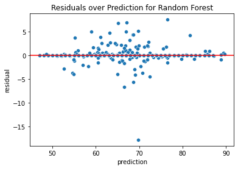

```python
residuals = y_test - y_prediction
c1 = pd.Series(residuals)
c1 = c1.reset_index()
c2 = pd.Series(y_prediction)
c2.name = 'prediction'
res_plot = pd.concat([c1, c2], axis=1)
res_plot = res_plot.rename(columns={"overall":"residuals"})

sns.scatterplot(data=res_plot, x="prediction", y='residuals')
plt.ylabel('residual')
plt.axhline(y=0, color='red');
plt.title("Residuals over Prediction for Random Forest")
```

Looking at the residual plot, we can see that most of the predictions have 0 as their residual. There are several misclassified players, but overall, most of them stick to the flat residual line.

# Classification

Now, we will try to classify soccer players on their positions based on their skill/physical scores.

### Preprocessing + Exploratory Data Analysis

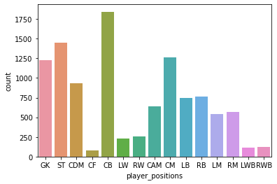

```python
sns.countplot(x=mldata["player_positions"])
```

This a frequency plot of the different player positions. We can see how uneven the data is. I will keep this distribution because I believe it is important account for this spread. I will first need to convert the position labels into classes by factorizing them.

We will try a Logistic Regression Classifier as a base line and then work with a Random Forest Classifier.

We will not use the R^2 score because it is not a good indicator for non linear data because this score relies on a variance pattern. If the data does not follow that linearity, then the score will not be representative of scoring that model.

We will not use ROC AUC score either because although it is good for multiclass classification, since the classes are pretty imbalanced, it will not be a good measurement.

Recall calculates out of the actual positive, how many did the model classify the positive correctly. This is useful for imbalanced datasets because the scoring is focused on classifying each class itself without considering all of them together.

F1 score is the harmonic mean of precision and recall. Both these factors contribute to the score. It puts an emphasis on classifying the positive classes correctly. Incorporates the importance of reducing false positives and negatives as well. This works well on imbalanced data by incorporating recall.

```python
mldata['classes'] = pd.factorize(mldata['player_positions'])[0]
X = mldata.drop(['overall', 'player_positions', 'classes'], axis=1)
y = mldata['classes']

X_train, X_test, y_train, y_test = train_test_split(X, y, test_size = 0.2, random_state = 42)
model = LogisticRegression()

model.fit(X_train, y_train)

y_pred = model.predict(X_test)

print("F1 Score: ", f1_score(y_test, y_pred, average='weighted'))
```

```
F1 Score:  0.43817628102808037
```

```python
clf = RandomForestClassifier(random_state=42)

param_grid = {"n_estimators": [10, 50, 100], "max_features": [2,5,8], "max_depth": [5, 10, 20]}
grid_search = GridSearchCV(estimator = clf, param_grid = param_grid,
                          cv = 10)

grid_search.fit(X_train, y_train)
best = grid_search.best_params_

clf2 = RandomForestClassifier(n_estimators=best["n_estimators"],
                             max_features = best["max_features"],
                             max_depth=best["max_depth"],
                             random_state=42)

clf2.fit(X_train, y_train)
y_pred = clf2.predict(X_test)

print("F1 Score: ", f1_score(y_test, y_pred, average='weighted'))
```

```
F1 Score:  0.609858535049193
```

## Communication of Insights

With this analysis and learning model, players, managers, teams, and even clubs can understand what makes up a good soccer player and help them identify which features they need to work on. We can continue to help build players and identify their weakness and strengths and to create more exciting teams. National teams for the World Cup expect only the greatest players and as better plays emerge, they will raise their expectations, so players need to figure out what they need to work on and must succeed. Games will become more exciting. I can't wait to see how the next world cup will be, learning more about soccer teams and players and see who will become the best of the best.